# Amami transportation study

Kang

## 数据构建

原始数据为2018年间到达奄美群岛的所有手机用户每天的轨迹。原始数据为来自[Agoop公司的人口流动点数据](https://agoop.co.jp/service/dynamic-population-data/)，是每个用户在一天中不同时刻的位置信息。有些人轨迹比较多，有些人被收集到的轨迹比较少，所以需要对数据进行清理。数据清理过程主要包括：从原始数据中去除轨迹点特别少的用户，因为如果轨迹点太少，我们无法分析其每天的移动轨迹；由于主要活动时间段为上午4时到晚上10时，因此这些时间段之外的轨迹点也去除；对于每个用户，只保留每10分钟内最早的一个数据点，使每个用户的数据密度相对一致。

对于数据，需要注意的是，这里的”用户”是指一天内的一位独立用户，例如，有个人两天都待在奄美群岛上，则会被识别为两个用户号（在数据中被称为”DailyID”）。

## 数据描述

按照季度和客源，可视化数据点的分布。如果觉得这个图可以的话，可以考虑是否要用到论文中，以及如果要用，跟我说一下要如何调整。

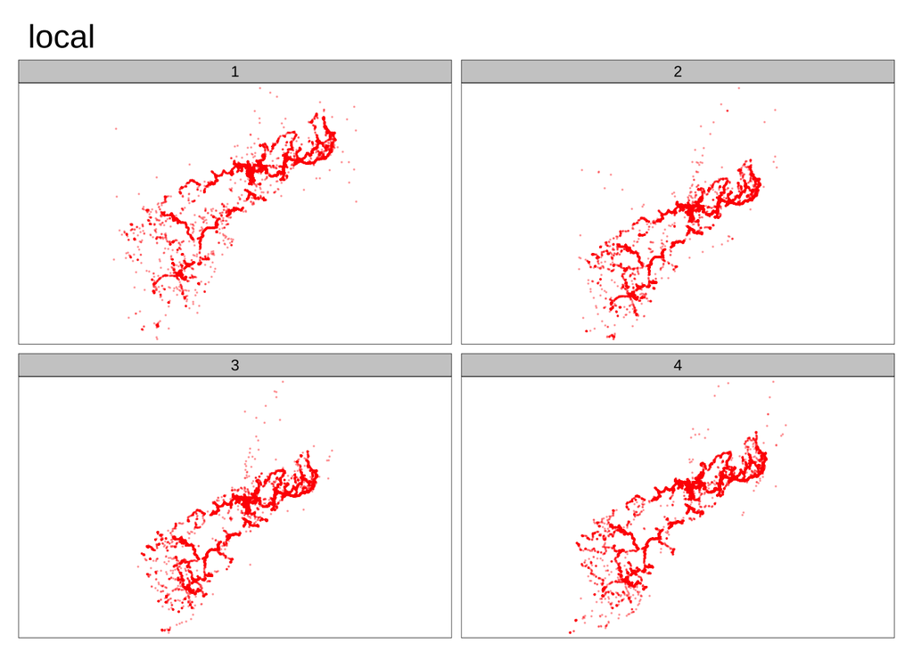

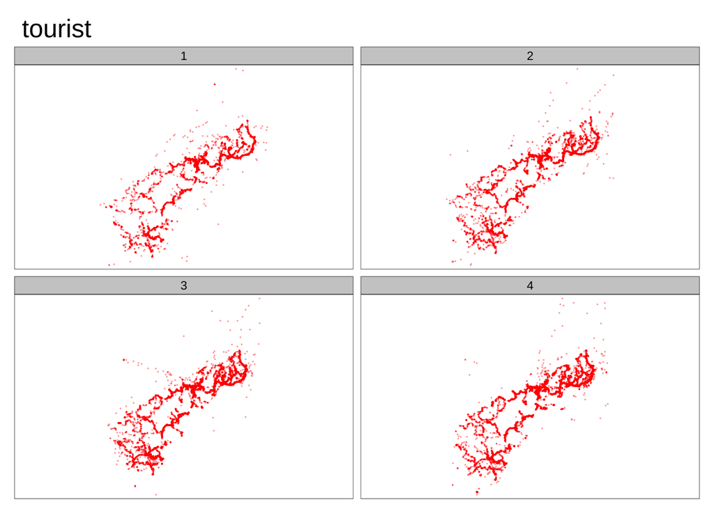

轨迹点中，本地人轨迹点和游客轨迹点的数量：本地人比较多。

```
##
##   local tourist
## 1565013  274021
```

各月份本地人和游客的人数如下，可见人口动态有季节差异。

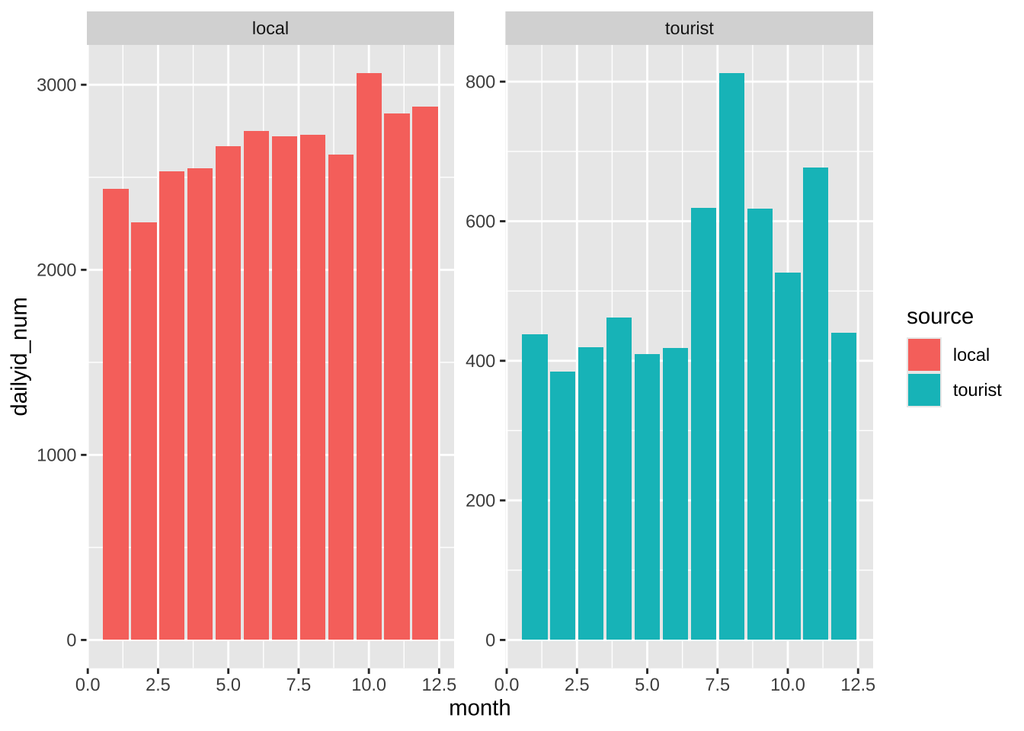

分季度来看人数的话，如下图。

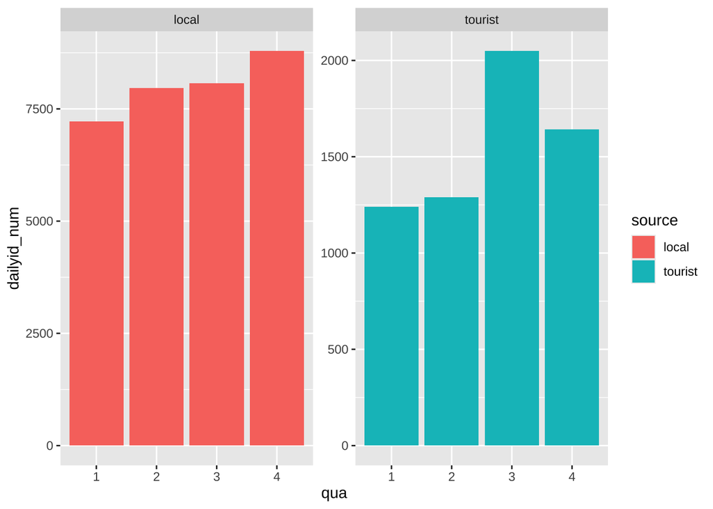

分客源分季度下，每个人每天经过地点数量如下。可见游客倾向于去更多地点。

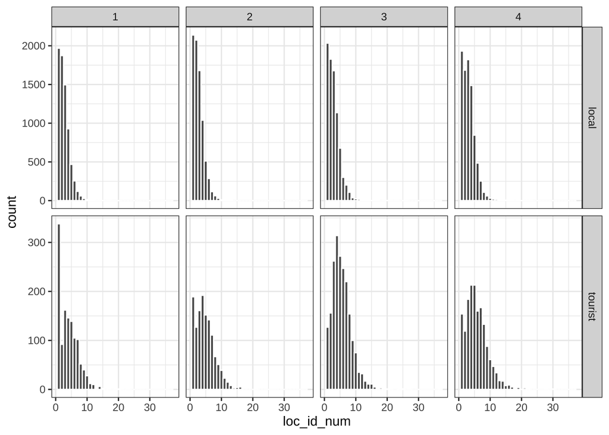

按照上次讨论结果，提取出图中每个柱子对应的数量最多的地点组合。例如，本地人第一季度中"1个地点"柱子对应的最多的"地点76"（看"loc_id_comb"列）。

[output not shown]

## 滞留时间和人数

### **术语定义**

原始数据中，每行数据表示一个人在某个时刻所在的位置，我们称之为一个**"轨迹点"**。例如，一个人的轨迹点序列可能是"76-76-75-r-76"，其中数字为定义地点编号，"r"为非定义地点（"road"）。那么这个人有5个轨迹点，包括4个定义地点的轨迹点和1个非定义地点的轨迹点。由于前面两个轨迹点都在76号地点，我们可以把它们合并，称之为一个**"事件"**（在这里是指在76号第一次停留的事件）。这样，我们可以将这个轨迹点序列合并成包含4个事件的事件序列：76-75-r-76。再进一步，这个序列涉及2个定义**地点**和1个非定义地点（当然，非定义地点也只有1个，就是"r"）。

对于每个事件，我们都可以计算一个**事件滞留时间**。结合对应地点的面积，还可以计算**事件单位面积滞留时间**。例如，刚才的例子中，可以计算2个76地点事件的滞留时间和1个75地点事件的滞留时间。将滞留时间按照地点合并起来，可以计算**地点滞留时间**和**地点单位面积滞留时间**。

对于每个地点，可以计算其在一定条件下（例如第一季度的本地人）的**滞留人数**和**单位面积滞留人数**。

### 事件滞留时间

事件滞留时间中位数如下。

[figure not shown]

[figure not shown]

事件单位面积滞留时间分布如下。

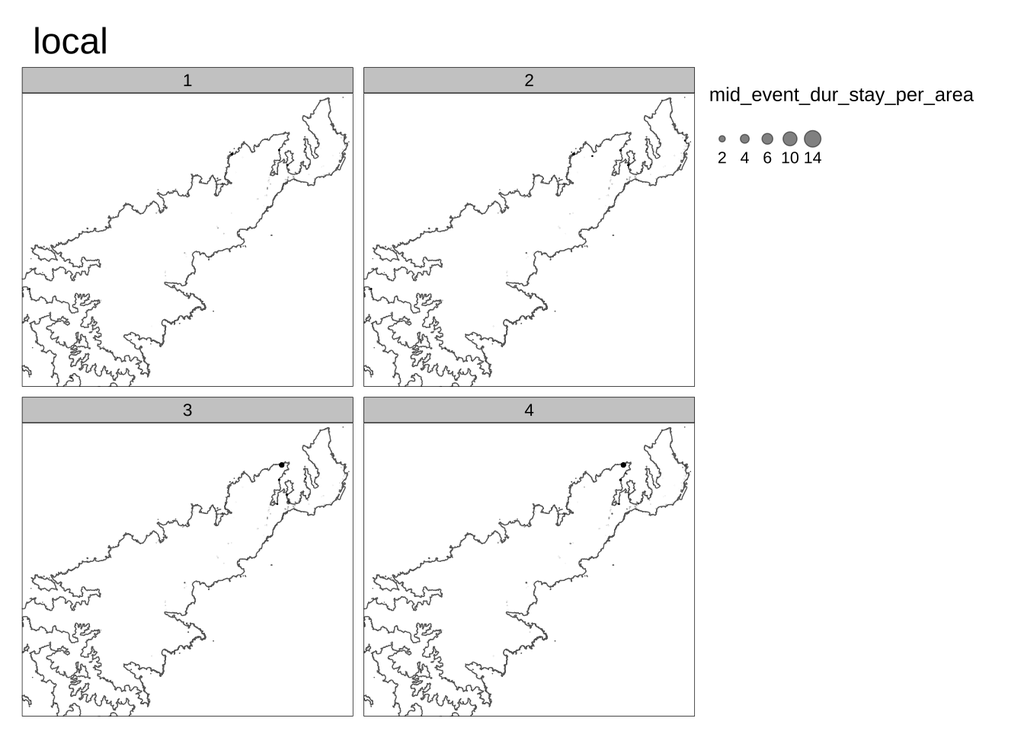

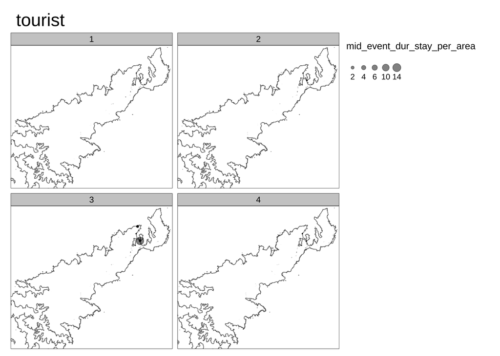

### 地点滞留时间

地点滞留时间中位数如下。

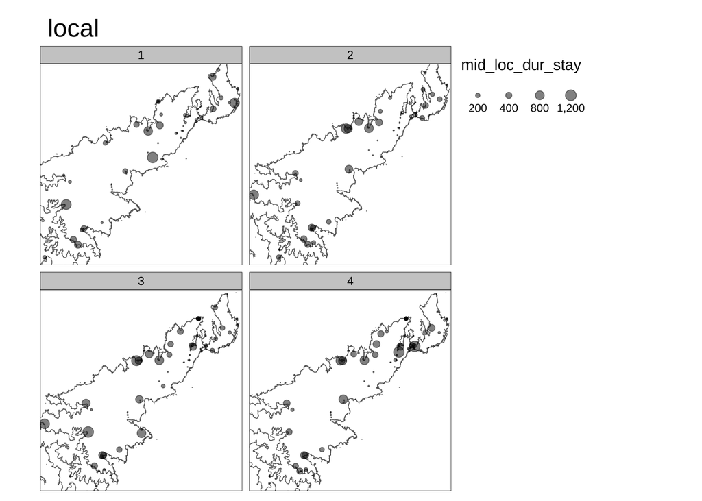

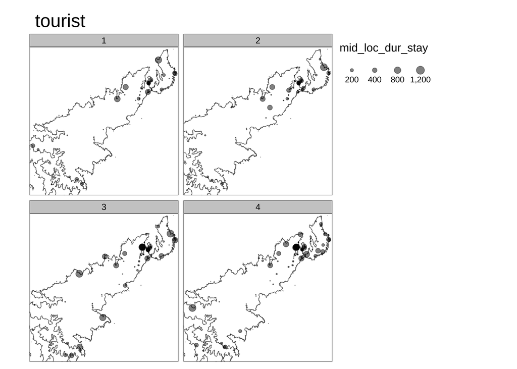

地点单位面积滞留时间中位数如下。

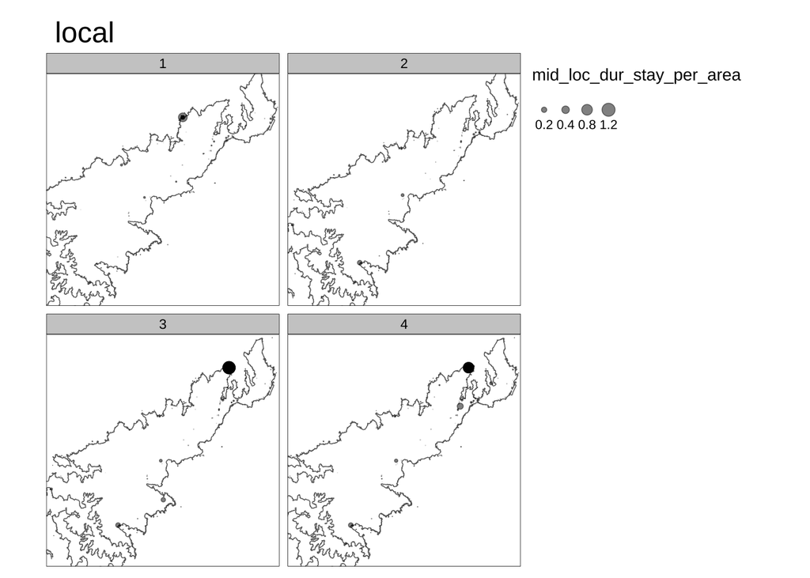

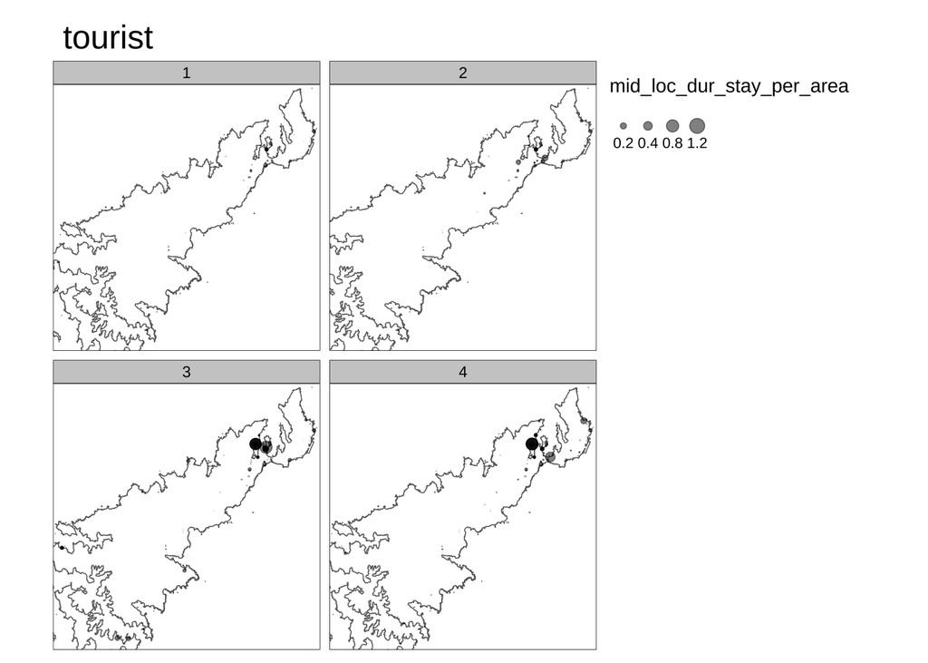

### 滞留人数

分客源和季节下滞留人数如下。

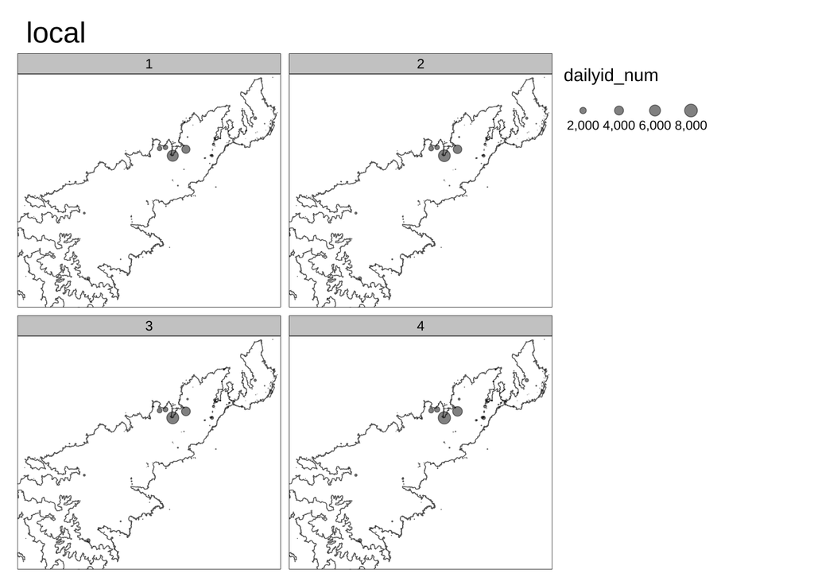

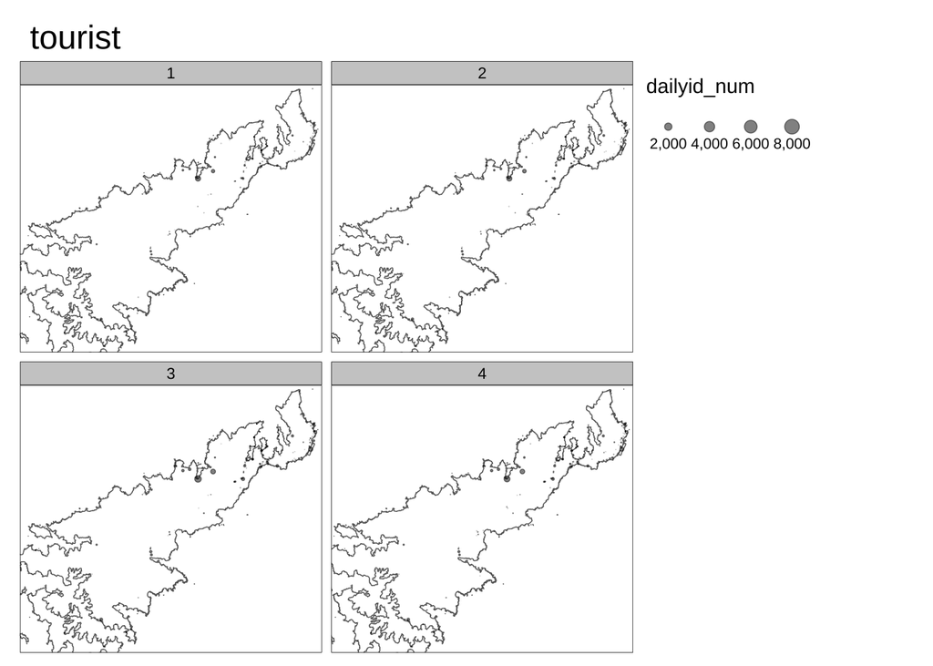

分季节分客源单位面积滞留人数如下。

```
##   0%  25%  50%  75% 100%
##    1    2    5   19 7457
```

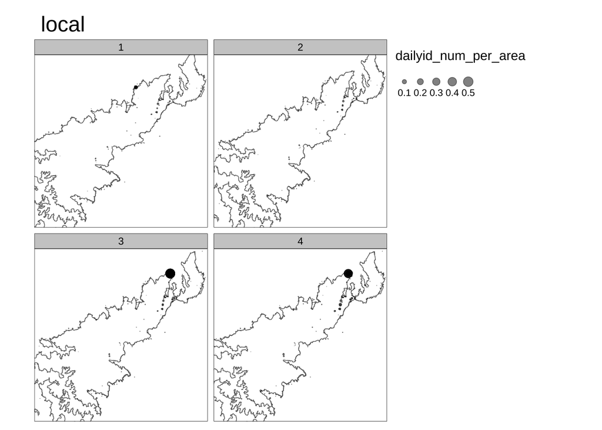

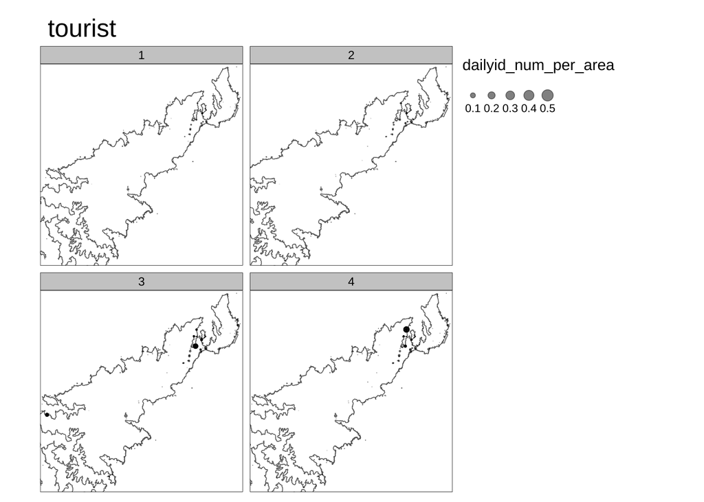

### 时间和人数关系

滞留人数和事件滞留时间的关系。

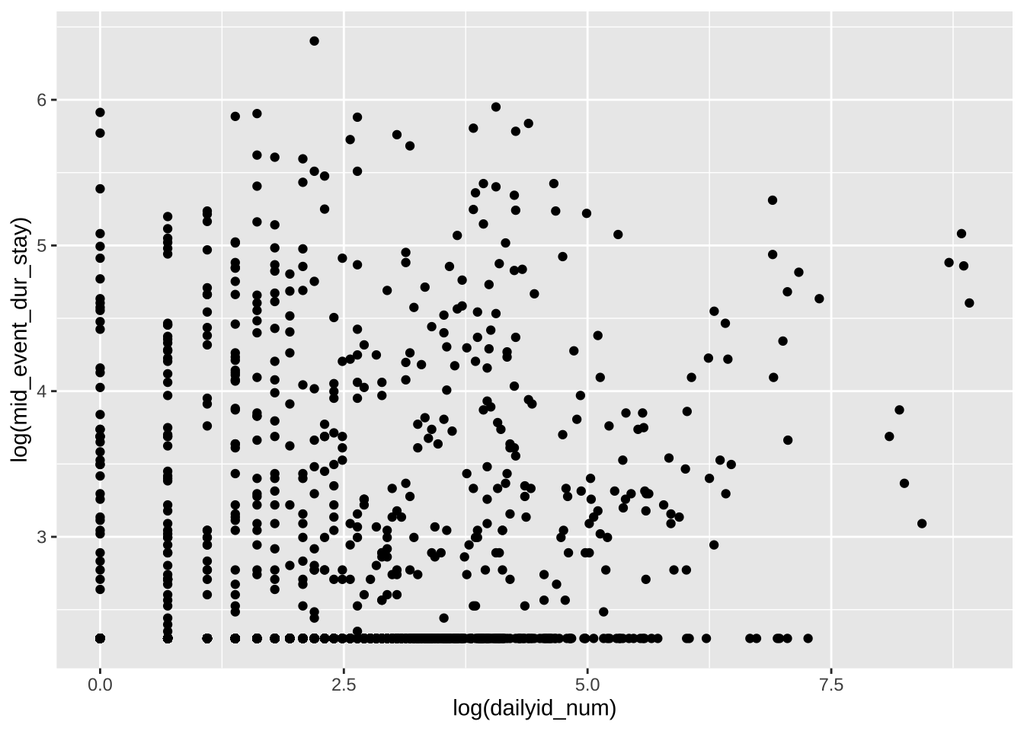

单位面积滞留人数和单位面积事件滞留时间的关系。

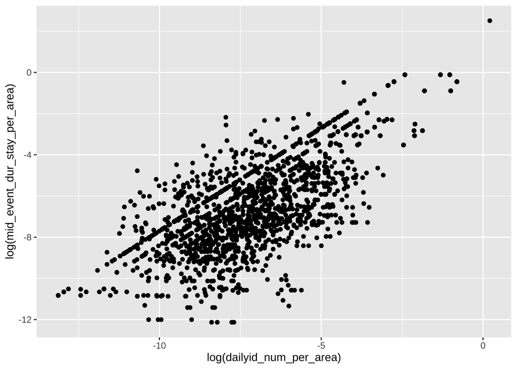

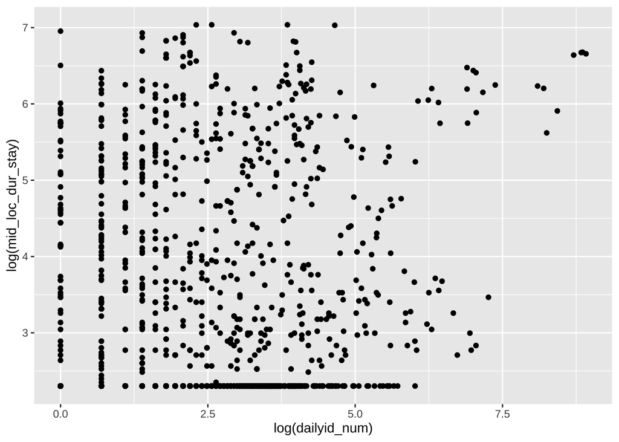

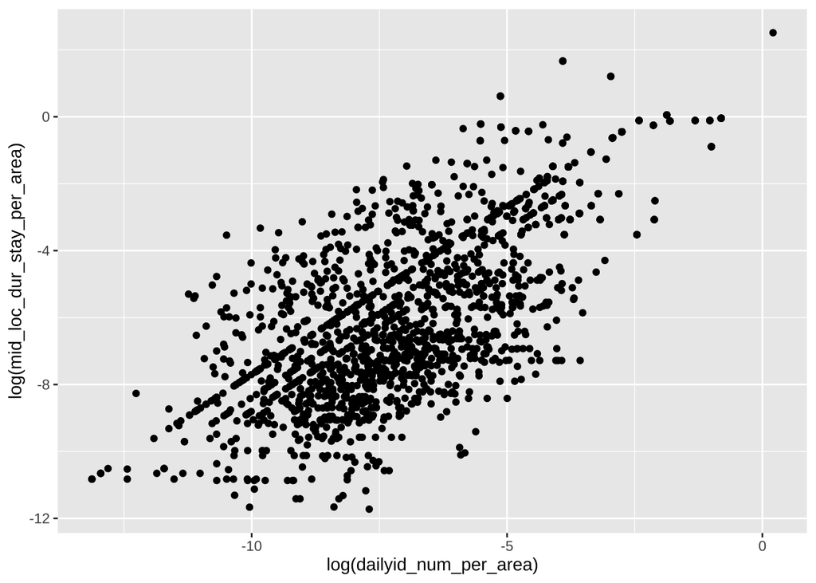

## 网络分析

见谢于松结果。